# Project: TMDB MOVIES DATA ANALYSIS

- Introduction
- Data Wrangling
- Exploratory Data Analysis
- Conclusions

## Introduction

> In this project i will be analyzing the data on TMDb movies. The TMDb dataset contains information about 10,000 movies collected from The Movie Database(TMDB), inluding user ratings and revenue.

### Some questions to be answered from this analysis include:

> 1. How has the growth of the film industry been over the years
> 2. Which genres are most popular from year to year
> 3. How is the performance of the movie industry per year in terms of revenue and budget
> 4. What are the top 10 budgeted movies?

```python
import pandas as pd
import numpy as np
import matplotlib.pyplot as plt
import seaborn as sns
%matplotlib inline
sns.set()
```

## Data Wrangling

### General Properties

```python
# loading the dataset
df = pd.read_csv('tmdb-movies.csv')
df.head(2)
```

|  | id | imdb_id | popularity | budget | revenue | original_title | cast | homepage | director | tagline | ... | overview | runtime | genres | production_companies | release_date | vote_count | vote_average | release_year | budget_adj | revenue_adj |
| --- | --- | --- | --- | --- | --- | --- | --- | --- | --- | --- | --- | --- | --- | --- | --- | --- | --- | --- | --- | --- | --- |
| 0 | 135397 | tt0369610 | 32.985763 | 150000000 | 1513528810 | Jurassic World | Chris Pratt\|Bryce Dallas Howard\|Irrfan Khan\|Vi... | http://www.jurassicworld.com/ | Colin Trevorrow | The park is open. | ... | Twenty-two years after the events of Jurassic ... | 124 | Action\|Adventure\|Science Fiction\|Thriller | Universal Studios\|Amblin Entertainment\|Legenda... | 6/9/15 | 5562 | 6.5 | 2015 | 1.379999e+08 | 1.392446e+09 |
| 1 | 76341 | tt1392190 | 28.419936 | 150000000 | 378436354 | Mad Max: Fury Road | Tom Hardy\|Charlize Theron\|Hugh Keays-Byrne\|Nic... | http://www.madmaxmovie.com/ | George Miller | What a Lovely Day. | ... | An apocalyptic story set in the furthest reach... | 120 | Action\|Adventure\|Science Fiction\|Thriller | Village Roadshow Pictures\|Kennedy Miller Produ... | 5/13/15 | 6185 | 7.1 | 2015 | 1.379999e+08 | 3.481613e+08 |

2 rows × 21 columns

```python
# Assessing the data
df.shape
```

```
(10866, 21)
```

```python
df.dtypes
```

```
id                        int64
imdb_id                  object
popularity              float64
budget                    int64
revenue                   int64
original_title           object
cast                     object
homepage                 object
director                 object
tagline                  object
keywords                 object
overview                 object
runtime                   int64
genres                   object
production_companies     object
release_date             object
vote_count                int64
vote_average            float64
release_year              int64
budget_adj              float64
revenue_adj             float64
dtype: object
```

```python
# Assessing the data
df.info()
```

```
<class 'pandas.core.frame.DataFrame'>
RangeIndex: 10866 entries, 0 to 10865
Data columns (total 21 columns):
 #   Column                Non-Null Count  Dtype
---  ------                --------------  -----
 0   id                    10866 non-null  int64
 1   imdb_id               10856 non-null  object
 2   popularity            10866 non-null  float64
 3   budget                10866 non-null  int64
 4   revenue               10866 non-null  int64
 5   original_title        10866 non-null  object
 6   cast                  10790 non-null  object
 7   homepage              2936 non-null   object
 8   director              10822 non-null  object
 9   tagline               8042 non-null   object
 10  keywords              9373 non-null   object
 11  overview              10862 non-null  object
 12  runtime               10866 non-null  int64
 13  genres                10843 non-null  object
 14  production_companies  9836 non-null   object
 15  release_date          10866 non-null  object
 16  vote_count            10866 non-null  int64
 17  vote_average          10866 non-null  float64
 18  release_year          10866 non-null  int64
 19  budget_adj            10866 non-null  float64
 20  revenue_adj           10866 non-null  float64
dtypes: float64(4), int64(6), object(11)
memory usage: 1.7+ MB
```

```python
# assessing the data
df.describe()
```

|  | id | popularity | budget | revenue | runtime | vote_count | vote_average | release_year | budget_adj | revenue_adj |
| --- | --- | --- | --- | --- | --- | --- | --- | --- | --- | --- |
| count | 10866.000000 | 10866.000000 | 1.086600e+04 | 1.086600e+04 | 10866.000000 | 10866.000000 | 10866.000000 | 10866.000000 | 1.086600e+04 | 1.086600e+04 |
| mean | 66064.177434 | 0.646441 | 1.462570e+07 | 3.982332e+07 | 102.070863 | 217.389748 | 5.974922 | 2001.322658 | 1.755104e+07 | 5.136436e+07 |
| std | 92130.136561 | 1.000185 | 3.091321e+07 | 1.170035e+08 | 31.381405 | 575.619058 | 0.935142 | 12.812941 | 3.430616e+07 | 1.446325e+08 |
| min | 5.000000 | 0.000065 | 0.000000e+00 | 0.000000e+00 | 0.000000 | 10.000000 | 1.500000 | 1960.000000 | 0.000000e+00 | 0.000000e+00 |
| 25% | 10596.250000 | 0.207583 | 0.000000e+00 | 0.000000e+00 | 90.000000 | 17.000000 | 5.400000 | 1995.000000 | 0.000000e+00 | 0.000000e+00 |
| 50% | 20669.000000 | 0.383856 | 0.000000e+00 | 0.000000e+00 | 99.000000 | 38.000000 | 6.000000 | 2006.000000 | 0.000000e+00 | 0.000000e+00 |
| 75% | 75610.000000 | 0.713817 | 1.500000e+07 | 2.400000e+07 | 111.000000 | 145.750000 | 6.600000 | 2011.000000 | 2.085325e+07 | 3.369710e+07 |
| max | 417859.000000 | 32.985763 | 4.250000e+08 | 2.781506e+09 | 900.000000 | 9767.000000 | 9.200000 | 2015.000000 | 4.250000e+08 | 2.827124e+09 |

```python
df.duplicated().sum()
```

```
1
```

```python
df.isnull().sum()
```

```
id                         0
imdb_id                   10
popularity                 0
budget                     0
revenue                    0
original_title             0
cast                      76
homepage                7930
director                  44
tagline                 2824
keywords                1493
overview                   4
runtime                    0
genres                    23
production_companies    1030
release_date               0
vote_count                 0
vote_average               0
release_year               0
budget_adj                 0
revenue_adj                0
dtype: int64
```

> By assessing the data above, we could notice the following:
> 1. The presence of null records
> 2. The presence of some irrelevant columns to our analysis
> 3. The presence of one duplicated row
> 4. The presence of wrong data types(e.g dtype for the release_date column)

### Data Cleaning

```python
# First, we drop the irrelevant columns
df.drop(['id','imdb_id','homepage','tagline','revenue','budget','keywords','overview','runtime','vote_average','vote_count'],axis=1,inplace=True)
```

> All the columns dropped were dropped because they will in no way help in the answering of the questions that i need answered and not necessarily because they are irrelevant. Columns like "home_page","tagline","keywords" were dropped because of their numerous null value records.

```python
# Dropping duplicates
df.drop_duplicates(inplace=True)
```

```python
# confirming that there are no duplicates
df.duplicated().sum().any()
```

```
False
```

```python
# Dropping null values
df.dropna(inplace=True)
```

```python
# confirming that there are no null values
df.isnull().sum().any()
```

```
False
```

```python
df.shape
```

```
(9772, 10)
```

```python
df.isnull().sum()
```

```
popularity              0
original_title          0
cast                    0
director                0
genres                  0
production_companies    0
release_date            0
release_year            0
budget_adj              0
revenue_adj             0
dtype: int64
```

```python
df.head()
```

|  | popularity | original_title | cast | director | genres | production_companies | release_date | release_year | budget_adj | revenue_adj |
| --- | --- | --- | --- | --- | --- | --- | --- | --- | --- | --- |
| 0 | 32.985763 | Jurassic World | Chris Pratt\|Bryce Dallas Howard\|Irrfan Khan\|Vi... | Colin Trevorrow | Action\|Adventure\|Science Fiction\|Thriller | Universal Studios\|Amblin Entertainment\|Legenda... | 6/9/15 | 2015 | 1.379999e+08 | 1.392446e+09 |
| 1 | 28.419936 | Mad Max: Fury Road | Tom Hardy\|Charlize Theron\|Hugh Keays-Byrne\|Nic... | George Miller | Action\|Adventure\|Science Fiction\|Thriller | Village Roadshow Pictures\|Kennedy Miller Produ... | 5/13/15 | 2015 | 1.379999e+08 | 3.481613e+08 |
| 2 | 13.112507 | Insurgent | Shailene Woodley\|Theo James\|Kate Winslet\|Ansel... | Robert Schwentke | Adventure\|Science Fiction\|Thriller | Summit Entertainment\|Mandeville Films\|Red Wago... | 3/18/15 | 2015 | 1.012000e+08 | 2.716190e+08 |
| 3 | 11.173104 | Star Wars: The Force Awakens | Harrison Ford\|Mark Hamill\|Carrie Fisher\|Adam D... | J.J. Abrams | Action\|Adventure\|Science Fiction\|Fantasy | Lucasfilm\|Truenorth Productions\|Bad Robot | 12/15/15 | 2015 | 1.839999e+08 | 1.902723e+09 |
| 4 | 9.335014 | Furious 7 | Vin Diesel\|Paul Walker\|Jason Statham\|Michelle ... | James Wan | Action\|Crime\|Thriller | Universal Pictures\|Original Film\|Media Rights ... | 4/1/15 | 2015 | 1.747999e+08 | 1.385749e+09 |

```python
# Investigating the number of 0 value we have in the revenue and budget and column
df[df['revenue_adj'] == 0]['revenue_adj'].count()
```

```
5022
```

```python
# Investigating the number of 0 value we have in the revenue and budget and column
df[df['budget_adj'] == 0]['budget_adj'].count()
```

```
4751
```

```python
# Having asssessed the number of 0s we have in the budget and revenue column, it is quite unreasonable and unexplanable because
# every movie released must have a budget and revenue regardless of how small or big. So, i will be changing this columns with
# 0s and filling them up with the average of each.

df['revenue_adj'].replace(0,df['revenue_adj'].mean(), inplace=True)
df['budget_adj'].replace(0,df['budget_adj'].mean(), inplace=True)
```

```python
# confirming if the 0s record in the revenue was successfully replaced
df[df['revenue_adj'] == 0]['revenue_adj'].count()
```

```
0
```

```python
# confirming if the 0s record in the budget was successfully replaced
df[df['budget_adj'] == 0]['budget_adj'].count()
```

```
0
```

```python
# changing the data type for the release date so as to get variations of different features over time
df['release_date'] = pd.to_datetime(df['release_date'])
df['release_month'] = df['release_date'].dt.month
```

```python
# Having both the release_year and release_month columns makes the release_date column irrelevant, so we then drop it.
df.drop(['release_date'],axis=1,inplace=True)
```

```python
# viewing progress
df.head()
```

|  | popularity | original_title | cast | director | genres | production_companies | release_year | budget_adj | revenue_adj | release_month |
| --- | --- | --- | --- | --- | --- | --- | --- | --- | --- | --- |
| 0 | 32.985763 | Jurassic World | Chris Pratt\|Bryce Dallas Howard\|Irrfan Khan\|Vi... | Colin Trevorrow | Action\|Adventure\|Science Fiction\|Thriller | Universal Studios\|Amblin Entertainment\|Legenda... | 2015 | 1.379999e+08 | 1.392446e+09 | 6 |
| 1 | 28.419936 | Mad Max: Fury Road | Tom Hardy\|Charlize Theron\|Hugh Keays-Byrne\|Nic... | George Miller | Action\|Adventure\|Science Fiction\|Thriller | Village Roadshow Pictures\|Kennedy Miller Produ... | 2015 | 1.379999e+08 | 3.481613e+08 | 5 |
| 2 | 13.112507 | Insurgent | Shailene Woodley\|Theo James\|Kate Winslet\|Ansel... | Robert Schwentke | Adventure\|Science Fiction\|Thriller | Summit Entertainment\|Mandeville Films\|Red Wago... | 2015 | 1.012000e+08 | 2.716190e+08 | 3 |
| 3 | 11.173104 | Star Wars: The Force Awakens | Harrison Ford\|Mark Hamill\|Carrie Fisher\|Adam D... | J.J. Abrams | Action\|Adventure\|Science Fiction\|Fantasy | Lucasfilm\|Truenorth Productions\|Bad Robot | 2015 | 1.839999e+08 | 1.902723e+09 | 12 |
| 4 | 9.335014 | Furious 7 | Vin Diesel\|Paul Walker\|Jason Statham\|Michelle ... | James Wan | Action\|Crime\|Thriller | Universal Pictures\|Original Film\|Media Rights ... | 2015 | 1.747999e+08 | 1.385749e+09 | 4 |

```python
# creating a column "roi" （wherby return on investment("roi") = revenue - budget / investment）to determine growth.
df['roi']=(df['revenue_adj']-df['budget_adj'])/df['budget_adj']
df.head()
```

|  | popularity | original_title | cast | director | genres | production_companies | release_year | budget_adj | revenue_adj | release_month | roi |
| --- | --- | --- | --- | --- | --- | --- | --- | --- | --- | --- | --- |
| 0 | 32.985763 | Jurassic World | Chris Pratt\|Bryce Dallas Howard\|Irrfan Khan\|Vi... | Colin Trevorrow | Action\|Adventure\|Science Fiction\|Thriller | Universal Studios\|Amblin Entertainment\|Legenda... | 2015 | 1.379999e+08 | 1.392446e+09 | 6 | 9.090192 |
| 1 | 28.419936 | Mad Max: Fury Road | Tom Hardy\|Charlize Theron\|Hugh Keays-Byrne\|Nic... | George Miller | Action\|Adventure\|Science Fiction\|Thriller | Village Roadshow Pictures\|Kennedy Miller Produ... | 2015 | 1.379999e+08 | 3.481613e+08 | 5 | 1.522909 |
| 2 | 13.112507 | Insurgent | Shailene Woodley\|Theo James\|Kate Winslet\|Ansel... | Robert Schwentke | Adventure\|Science Fiction\|Thriller | Summit Entertainment\|Mandeville Films\|Red Wago... | 2015 | 1.012000e+08 | 2.716190e+08 | 3 | 1.683984 |
| 3 | 11.173104 | Star Wars: The Force Awakens | Harrison Ford\|Mark Hamill\|Carrie Fisher\|Adam D... | J.J. Abrams | Action\|Adventure\|Science Fiction\|Fantasy | Lucasfilm\|Truenorth Productions\|Bad Robot | 2015 | 1.839999e+08 | 1.902723e+09 | 12 | 9.340891 |
| 4 | 9.335014 | Furious 7 | Vin Diesel\|Paul Walker\|Jason Statham\|Michelle ... | James Wan | Action\|Crime\|Thriller | Universal Pictures\|Original Film\|Media Rights ... | 2015 | 1.747999e+08 | 1.385749e+09 | 4 | 6.927628 |

```python
# Splitting the "genres" column and taking the first genre as the primary genre while ignoring the others
df['primary_genre'] = df['genres'].apply(lambda x: x.split('|')[0])

# We then drop the "genres" column
df.drop(['genres'], axis =1, inplace=True)
df.head(3)
```

|  | popularity | original_title | cast | director | production_companies | release_year | budget_adj | revenue_adj | release_month | roi | primary_genre |
| --- | --- | --- | --- | --- | --- | --- | --- | --- | --- | --- | --- |
| 0 | 32.985763 | Jurassic World | Chris Pratt\|Bryce Dallas Howard\|Irrfan Khan\|Vi... | Colin Trevorrow | Universal Studios\|Amblin Entertainment\|Legenda... | 2015 | 1.379999e+08 | 1.392446e+09 | 6 | 9.090192 | Action |
| 1 | 28.419936 | Mad Max: Fury Road | Tom Hardy\|Charlize Theron\|Hugh Keays-Byrne\|Nic... | George Miller | Village Roadshow Pictures\|Kennedy Miller Produ... | 2015 | 1.379999e+08 | 3.481613e+08 | 5 | 1.522909 | Action |
| 2 | 13.112507 | Insurgent | Shailene Woodley\|Theo James\|Kate Winslet\|Ansel... | Robert Schwentke | Summit Entertainment\|Mandeville Films\|Red Wago... | 2015 | 1.012000e+08 | 2.716190e+08 | 3 | 1.683984 | Adventure |

```python
# Splitting the "production_companies" column and taking the first production company as the lead production company and taking
# it into account while ignoring the others
df['main_prod_company'] = df['production_companies'].apply(lambda x: x.split('|')[0])

# We then drop the "production_companies" column
df.drop(['production_companies'], axis=1, inplace=True)
df.head(3)
```

|  | popularity | original_title | cast | director | release_year | budget_adj | revenue_adj | release_month | roi | primary_genre | main_prod_company |
| --- | --- | --- | --- | --- | --- | --- | --- | --- | --- | --- | --- |
| 0 | 32.985763 | Jurassic World | Chris Pratt\|Bryce Dallas Howard\|Irrfan Khan\|Vi... | Colin Trevorrow | 2015 | 1.379999e+08 | 1.392446e+09 | 6 | 9.090192 | Action | Universal Studios |
| 1 | 28.419936 | Mad Max: Fury Road | Tom Hardy\|Charlize Theron\|Hugh Keays-Byrne\|Nic... | George Miller | 2015 | 1.379999e+08 | 3.481613e+08 | 5 | 1.522909 | Action | Village Roadshow Pictures |
| 2 | 13.112507 | Insurgent | Shailene Woodley\|Theo James\|Kate Winslet\|Ansel... | Robert Schwentke | 2015 | 1.012000e+08 | 2.716190e+08 | 3 | 1.683984 | Adventure | Summit Entertainment |

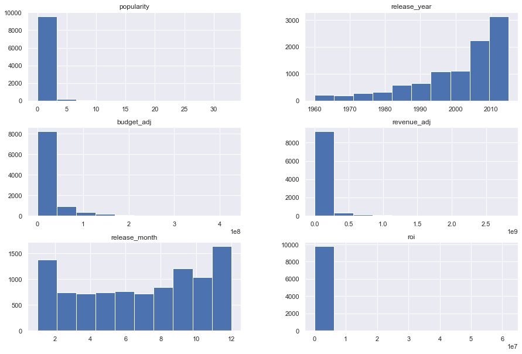

```python
# We first observe the data to check for outliers and it is distributed. This is to check if the data needs further cleaning and
# if it ready for Exploratory Data Analysis.
df.hist(figsize=(15,10));
```

### Our data has now been cleaned!!!!!

#### It is now ready for Exploratory Data Analysis and ready for our questions to be answered.

## Exploratory Data Analysis

### Research Question 1: How has the growth of the film industry been over the years

```python
df['release_year'].value_counts()
```

```
2014    635
2013    567
2015    558
2012    498
2009    474
2011    456
2008    441
2010    420
2007    389
2006    350
2005    323
2003    254
2004    253
2002    241
1999    212
```

[output cut: 42 more lines]

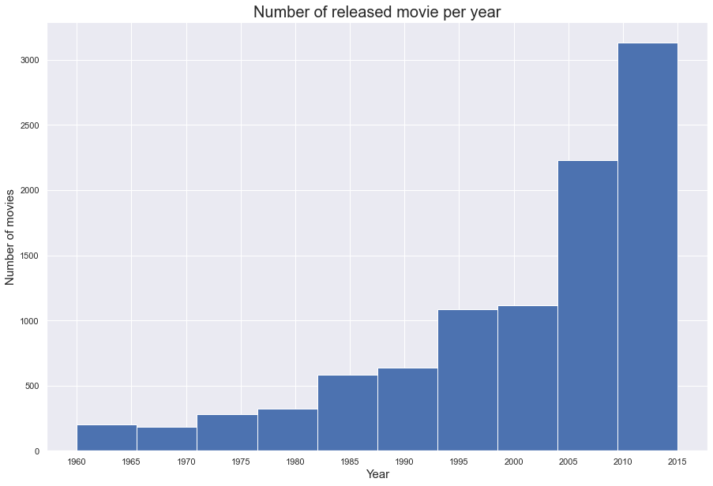

```python
df['release_year'].plot(kind = 'hist', figsize = (15,10))
plt.title('Number of released movie per year', fontsize = 20)
plt.xlabel('Year', fontsize=15)
plt.ylabel('Number of movies', fontsize=15)
plt.xticks(range(1960,2017,5))
plt.show()
```

#### As clearly displayed in the graph above, the movie industry is a fast growing business. There has been a massive growth since after 90s and the release of movie skyrocketed after 2005.

### Research Question 1b: What are the Genres with highest revenues per year

```python
df['primary_genre'].unique()
```

```
array(['Action', 'Adventure', 'Western', 'Science Fiction', 'Drama',
       'Family', 'Comedy', 'Crime', 'Romance', 'War', 'Mystery',
       'Thriller', 'Fantasy', 'History', 'Animation', 'Horror', 'Music',
       'Documentary', 'TV Movie', 'Foreign'], dtype=object)
```

```python
# To get a dataframe that outputs the genre with the highest revenue per year
genre_max_rev = df.groupby(['release_year'])[['primary_genre','revenue_adj']].max()
genre_max_rev.head()
```

| release_year | primary_genre | revenue_adj |
| --- | --- | --- |
| 1960 | Thriller | 4.423780e+08 |
| 1961 | Western | 1.574815e+09 |
| 1962 | Western | 5.045914e+08 |
| 1963 | Romance | 5.617734e+08 |
| 1964 | Western | 8.780804e+08 |

```python
# converting the column "primary_genre" to an index alongside release_year.
genre_max_rev = genre_max_rev.set_index(['primary_genre'], append=True)
genre_max_rev.head()
```

| release_year | primary_genre | revenue_adj |
| --- | --- | --- |
| 1960 | Thriller | 4.423780e+08 |
| 1961 | Western | 1.574815e+09 |
| 1962 | Western | 5.045914e+08 |
| 1963 | Romance | 5.617734e+08 |
| 1964 | Western | 8.780804e+08 |

```python
# Sorting the values to make the visibility more pleasurable
genre_max_rev = genre_max_rev.sort_values(by=['revenue_adj'],ascending=False)
genre_max_rev.head()
```

| release_year | primary_genre | revenue_adj |
| --- | --- | --- |
| 2009 | War | 2.827124e+09 |
| 1977 | Western | 2.789712e+09 |
| 1997 | Thriller | 2.506406e+09 |
| 1973 | Western | 2.167325e+09 |
| 1975 | Western | 1.907006e+09 |

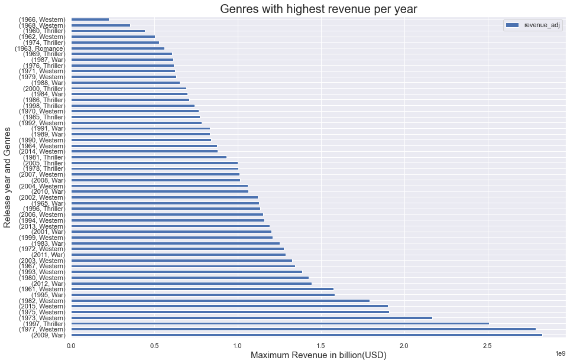

```python
# visualizing the data
genre_max_rev.plot(kind='barh', figsize = (15,10))
plt.title('Genres with highest revenue per year', fontsize = 20)
plt.xlabel('Maximum Revenue in billion(USD)', fontsize=15)
plt.ylabel('Release year and Genres',fontsize=15)
plt.show()
```

### Research Question 1c: How is the performance of the movie industry per year in terms of revenue and budget?

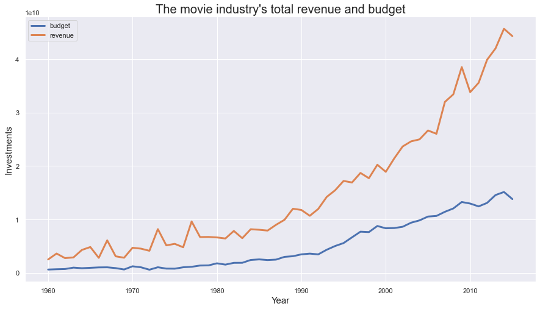

```python
# Grouping by release_year and adding the budget for each release_year
# Grouping by release_year and adding the revenue for each release_year
# visualize the data
budget = df.groupby(['release_year']).budget_adj.sum()
revenue = df.groupby(['release_year']).revenue_adj.sum()
fig = plt.figure(figsize=(15,8))
plt.plot(budget, linewidth=3)
plt.plot(revenue, linewidth=3)
plt.title("The movie industry's total revenue and budget", fontsize = 20)
plt.xlabel("Year", fontsize=15)
plt.ylabel("Investments", fontsize=15)
plt.legend(['budget','revenue'])
plt.show()
```

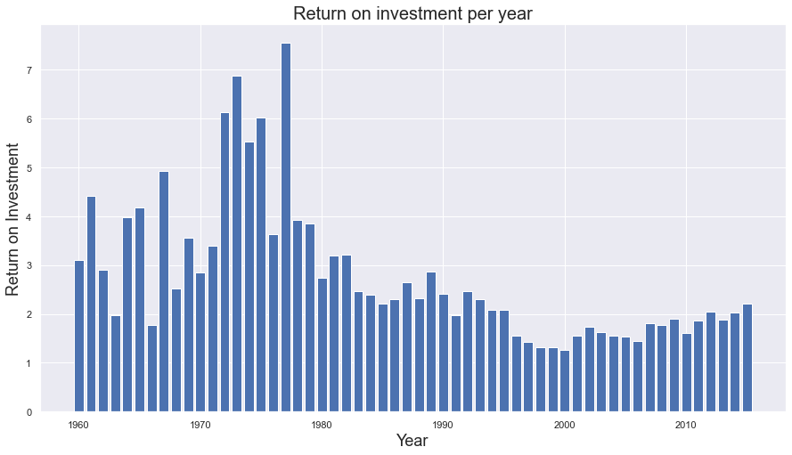

```python
# Now to get the Return on Investment of the movie industry over the years
# visualizing the data
roi = (revenue - budget)/budget
fig = plt.figure(figsize=(15,8))
plt.bar(roi.index,roi)
plt.title('Return on investment per year', fontsize=20)
plt.xlabel('Year', fontsize=18)
plt.ylabel('Return on Investment', fontsize=18)
plt.show()
```

#### As seen above, the return on investment was at its highest between 1970 and 1980 and massively decreased in the late 90s. it has been growing as of late i.e after 2010 although the growth is nothing compared to that which happened in the 70s.

### Research Question 1d: Has the popularity affected the revenue and budget in anyway?

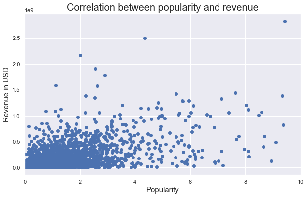

```python
# let's create a fuction that will take the data  we will need for the visualization as well as for its basic editing and output
# the required scatter plot needed for this representation. It is created so it can be re-used for the budget plot

def plot(x,y,title,xlabel,ylabel):
    fig = plt.figure(figsize=(10,6))
    plt.scatter(x,y)
    plt.title(title, fontsize=20)
    plt.xlabel(xlabel, fontsize=15)
    plt.ylabel(ylabel, fontsize=15)
    plt.xlim(0,10)
    return plt.show()

plot(df['popularity'],df['revenue_adj'],'Correlation between popularity and revenue','Popularity','Revenue in USD')
```

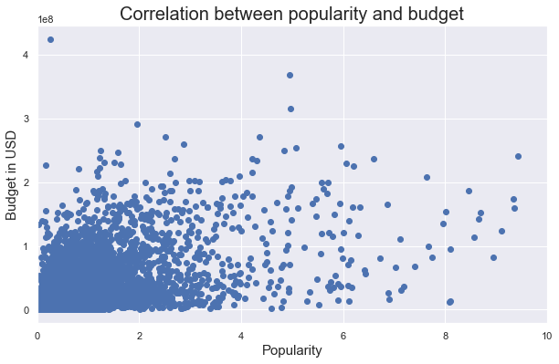

```python
# Re-using the function already created above

plot(df['popularity'],df['budget_adj'],'Correlation between popularity and budget','Popularity','Budget in USD')
```

### Research Question 1e: Which month is associated with the highest revenue and budget

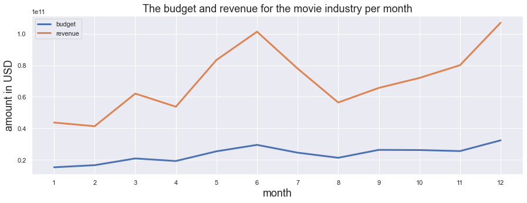

```python
# grouping by months and then adding the budget and revenue for each month
# visualizing the data
budget_month= df.groupby('release_month').sum().budget_adj
revenue_month= df.groupby('release_month').sum().revenue_adj
fig = plt.figure(figsize=(15,5))
plt.plot(budget_month, linewidth=3)
plt.plot(revenue_month,linewidth=3)
plt.title('The budget and revenue for the movie industry per month',fontsize=18)
plt.xlabel('month',fontsize=18)
plt.ylabel('amount in USD',fontsize=18)
plt.xticks(range(1,13))
plt.legend(['budget','revenue'])
plt.show()
```

#### As can be seen above, the month with the highest revenue and budget is the 12th month which is "December" and with very little gap between them we have the 6th month which is "June".

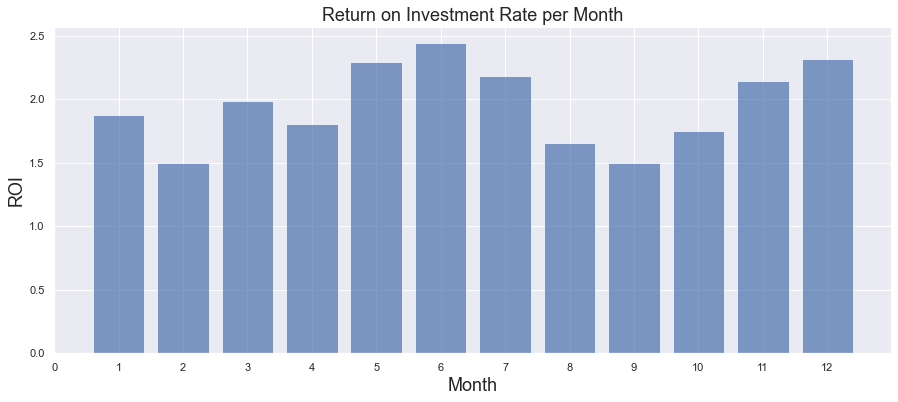

```python
# Let's now get the Return on investent per month
roi_m= (revenue_month-budget_month)/(budget_month)
fig = plt.figure(figsize=(15,6))
plt.bar(roi_m.index,roi_m,alpha = 0.7)
plt.title('Return on Investment Rate per Month',fontsize=18)
plt.xlabel('Month',fontsize=18)
plt.xticks(range(0,13))
plt.ylabel('ROI',fontsize=18)
plt.show()
```

#### As seen on the graph, the ROI for june and December seem to be equal. So, it can be said that the most profit is generated in the month of June and December.

### Research Question 2: How has the movies and genres evolved over the years

### 2a. What are the top 10 budgeted movies?(i.e the most expensive movies)

```python
# Let's group the data by title and get their various budgets
title = df.groupby(['original_title']).budget_adj.sum()
title = title.sort_values(ascending=False)
title
```

```
original_title
The Warrior's Way                              4.250000e+08
Pirates of the Caribbean: On Stranger Tides    3.683713e+08
King Kong                                      3.230894e+08
Godzilla                                       3.212750e+08
Pirates of the Caribbean: At World's End       3.155006e+08
                                                   ...
Death of a Superhero                           2.908194e+00
Lost & Found                                   1.309053e+00
Angus, Thongs and Perfect Snogging             1.012787e+00
Love, Wedding, Marriage                        9.693980e-01
Fear Clinic                                    9.210911e-01
Name: budget_adj, Length: 9512, dtype: float64
```

```python
# Then picking only the top 10
title = title[:10]
```

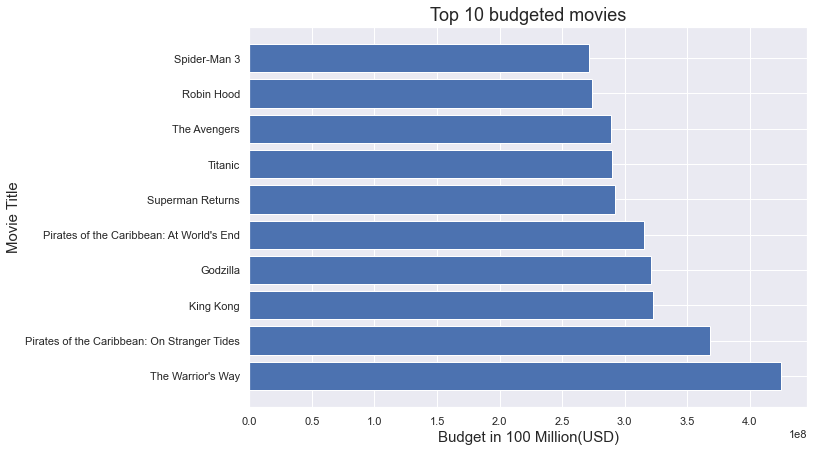

```python
fig = plt.figure(figsize=(10,7))
plt.barh(title.index, title)
plt.title('Top 10 budgeted movies', fontsize=18)
plt.xlabel('Budget in 100 Million(USD)', fontsize=15)
plt.ylabel('Movie Title', fontsize=15)
plt.show()
```

#### As seen from the bar chart above, the most budgeted movie is "The Warrior's Way" followed by "Pirates of the Carribean: On the Stranger Tides".

### Research Question 2b: What are the top 10 genres with the highest number of movies released

```python
# counting the values present in the genres
df['primary_genre'].value_counts()[:10]
```

```
Drama          2223
Comedy         2084
Action         1479
Horror          853
Adventure       550
Thriller        474
Crime           361
Animation       346
Documentary     264
Fantasy         253
Name: primary_genre, dtype: int64
```

[figure not shown]

```python
# visualizing the first 10 in the data
genre = df['primary_genre'].value_counts()[:10]
fig = plt.figure(figsize=(16,13))
genre.plot.pie()
plt.title('Film Genres', fontsize=18)
plt.xlabel('genre', fontsize=18)
plt.ylabel('count', fontsize=18)
plt.legend(['drama','comedy','thriller','action','romance','horror','adventure','crime'], loc='best',ncol=2)
plt.show()
```

#### As seen from the plot above, the genre "Drama" is the genre with highest movie released which is 2223 and followed closely by Comedy with 2084 movies released and so on.

### Research Question 2c: Which genre is growing fastest compared to others

```python
# creating a new variable with the exact data in df to allow for some variations without affecting the original data
df1 = df
# creating a new column and filling it all up with 1 to be able to sum them up for later calculation
df1['num'] = df['revenue_adj']/df['revenue_adj']
# grouping by release_year and genre and then getting the number of movies for each
df2 = df1.groupby(['release_year','primary_genre']).num.sum()
df3 = pd.DataFrame(df2)
```

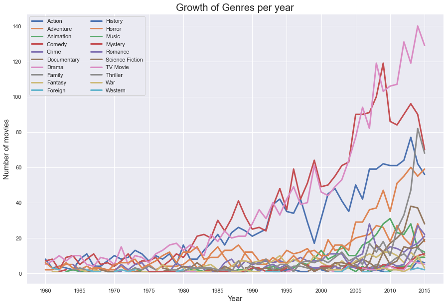

```python
# creating a pivot table to make visualization of data easier
df3_pivot = df3.pivot_table(index='release_year',columns='primary_genre',values='num')

fig = plt.figure()
df3_pivot.plot(figsize=(15,10), linewidth=3)
plt.title('Growth of Genres per year', fontsize=20)
plt.xlabel('Year', fontsize=15)
plt.ylabel('Number of movies', fontsize=15)
plt.xticks(range(1960,2017,5))
plt.legend(ncol=2)
plt.show()
```

#### As seen from the graph above, the genre "Drama" is the biggest genre in the movie industry and also has the fastest growing rate over the years.

### Research Question 2d: How much revenue is made by the top 5 most popular movie directors

```python
# we groupby the "director" column and sum the "popularity" column
pop_sum = df.groupby('director').popularity.sum()
```

```python
# we group by the "director" column and sum the revenue
rev_sum = df.groupby('director').revenue_adj.sum()
rev_sum
```

```
director
 FrÃ©dÃ©ric Jardin            3.255239e+03
A. Todd Smith                 5.705309e+07
Aaron Blaise|Robert Walker    2.963382e+02
Aaron Hann|Mario Miscione     5.705309e+07
Aaron Harvey                  5.705309e+07
                                  ...
Ã‡aÄŸan Irmak                 5.705309e+07
Ã‰mile Gaudreault             3.593753e+06
Ã‰ric Besnard                 5.705309e+07
Ã‰tienne Chatiliez            1.711593e+08
Ã€lex Pastor|David Pastor     5.897584e+06
Name: revenue_adj, Length: 4505, dtype: float64
```

```python
# We then use the concat function t0 combine both of them and we sort them in descending order in terms of "popularity"
dir_five = pd.concat([pop_sum,rev_sum], axis=1).sort_values(by=['popularity'], ascending=False)[:5]
dir_five
```

| director | popularity | revenue_adj |
| --- | --- | --- |
| Christopher Nolan | 61.786664 | 4.221315e+09 |
| Steven Spielberg | 54.378995 | 1.531655e+10 |
| Peter Jackson | 49.067904 | 7.133954e+09 |
| Ridley Scott | 46.213770 | 4.276619e+09 |
| Quentin Tarantino | 45.991796 | 1.736579e+09 |

```python
# converting the column "popularity" to an index alongside director.
dir_five = dir_five .set_index(['popularity'], append=True)
dir_five
```

| director | popularity | revenue_adj |
| --- | --- | --- |
| Christopher Nolan | 61.786664 | 4.221315e+09 |
| Steven Spielberg | 54.378995 | 1.531655e+10 |
| Peter Jackson | 49.067904 | 7.133954e+09 |
| Ridley Scott | 46.213770 | 4.276619e+09 |
| Quentin Tarantino | 45.991796 | 1.736579e+09 |

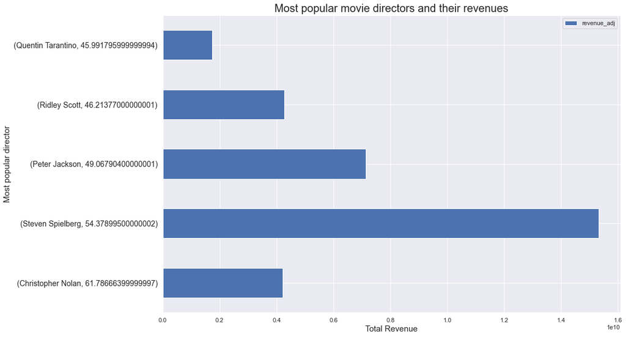

```python
dir_five.plot(kind='barh', figsize = (15,10))
plt.title('Most popular movie directors and their revenues', fontsize = 20)
plt.xlabel('Total Revenue', fontsize=15)
plt.ylabel('Most popular director',fontsize=15)
plt.yticks(fontsize=14)
plt.show()
```

#### As can be deduced from the graph above, being the most popular director doesn't necessarily mean you would have the highest revenue. So the popularity of the directors has no influence on the revenue generated by each director. The most popular director made a total revenue of around 4 billion USD while the second most popular director made around 15 billion USD which proves the statement made earlier.

### Research Question 2e: Top 5 movies with the highest revenue

```python
# querying for the 'revenue_adj' and 'original_title' with the top 5 highest revenue
movie_rev = df.nlargest(5,'revenue_adj')[['original_title','revenue_adj']]
movie_rev
```

|  | original_title | revenue_adj |
| --- | --- | --- |
| 1386 | Avatar | 2.827124e+09 |
| 1329 | Star Wars | 2.789712e+09 |
| 5231 | Titanic | 2.506406e+09 |
| 10594 | The Exorcist | 2.167325e+09 |
| 9806 | Jaws | 1.907006e+09 |

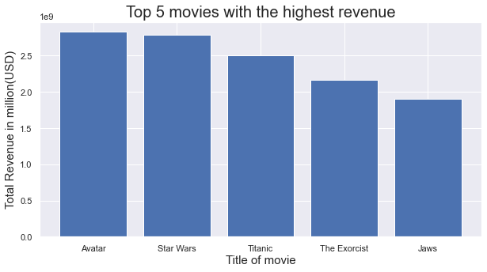

```python
fig = plt.figure(figsize=(10,5))
plt.bar(movie_rev['original_title'], movie_rev['revenue_adj'])
plt.title('Top 5 movies with the highest revenue', fontsize = 20)
plt.xlabel('Title of movie', fontsize=15)
plt.ylabel('Total Revenue in million(USD)',fontsize=15)
plt.show()
```

### Research Question 2f: Which genre has the most budget, revenue?(Film Budget and Revenue for Different Genres)

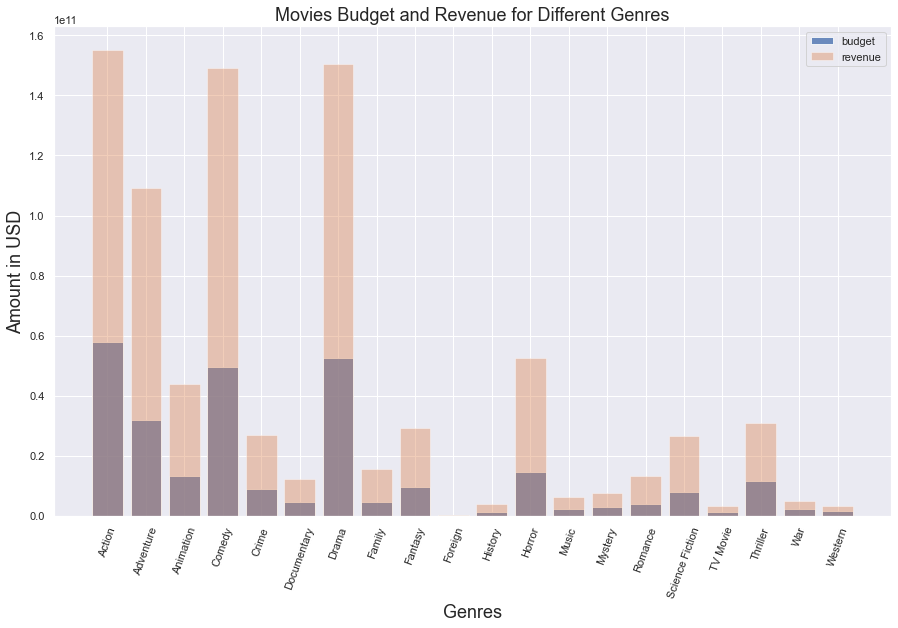

```python
# We first group the data by "primary_genre" and then sum the revenue and budget for each

gen_budget = df.groupby('primary_genre').sum().budget_adj
gen_rev = df.groupby('primary_genre').sum().revenue_adj
fig = plt.figure(figsize=(15,9))
plt.bar(gen_budget.index,gen_budget,alpha=0.8)
plt.bar(gen_rev.index,gen_rev,alpha=0.4)
plt.xticks(rotation=70)
plt.title('Movies Budget and Revenue for Different Genres', fontsize=18)
plt.xlabel('Genres', fontsize=18)
plt.ylabel('Amount in USD', fontsize=18)
plt.xticks()
plt.legend(['budget','revenue'])
plt.show()
```

#### As seen in the graph, the genres "Action","Drama" and "Comedy" are the top 3 most budgeted genre in the movie industry i.e They are the most expensive genre.

### Reasearch Question 3: How has production companies evolved over the years

### Reasearch Question 3a: What was the top 10 highest revenue generated by a production company and in what year was it made

```python
# grouping by production companies and release year and then sum the revenues
# we then sort values in descending order and selecting the first ten
prod_rev = df.groupby(['main_prod_company','release_year'])['revenue_adj'].sum().sort_values(ascending=False)[:10]
prod_rev
```

```
main_prod_company        release_year
Walt Disney Pictures     2010            3.691186e+09
Paramount Pictures       1997            3.531610e+09
Universal Pictures       2015            3.496773e+09
Columbia Pictures        2012            3.363526e+09
Ingenious Film Partners  2009            3.287956e+09
Paramount Pictures       2011            3.212258e+09
Universal Pictures       2012            2.820684e+09
Walt Disney Pictures     2003            2.794274e+09
Lucasfilm                1977            2.789712e+09
Walt Disney Pictures     2013            2.743767e+09
Name: revenue_adj, dtype: float64
```

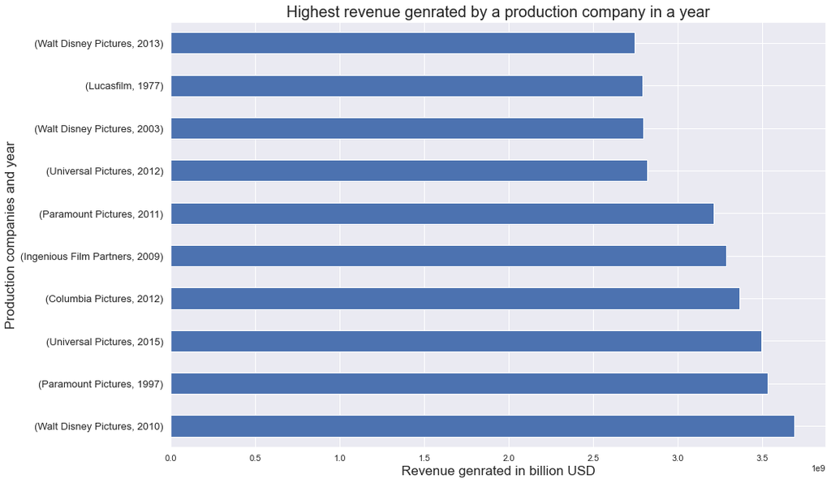

```python
fig = plt.figure(figsize=(15,10))
prod_rev.plot(kind='barh')
plt.title('Highest revenue genrated by a production company in a year', fontsize=20)
plt.xlabel('Revenue genrated in billion USD', fontsize=17)
plt.ylabel('Production companies and year', fontsize=17)
plt.yticks(fontsize=13)
plt.show()
```

#### As can be seen on the graph, the production company with the highest revenue of around 3.7billion USD for a year is "Walt Disney Pictures" and this was generated in the year "2010".

### Research Question 3b: What are the top 10 most successful production companies based on return on investment

```python
df.head(1)
```

|  | popularity | original_title | cast | director | release_year | budget_adj | revenue_adj | release_month | roi | primary_genre | main_prod_company | num |
| --- | --- | --- | --- | --- | --- | --- | --- | --- | --- | --- | --- | --- |
| 0 | 32.985763 | Jurassic World | Chris Pratt\|Bryce Dallas Howard\|Irrfan Khan\|Vi... | Colin Trevorrow | 2015 | 1.379999e+08 | 1.392446e+09 | 6 | 9.090192 | Action | Universal Studios | 1.0 |

```python
# grouping by production companies and then sum the return on investment
# we then sort values in descending order and selecting the first ten
prod_roi = df.groupby(['main_prod_company'])['roi'].sum().sort_values(ascending=False)[:10]
prod_roi
```

```
main_prod_company
Dry County Films              6.194078e+07
Paramount Pictures            5.633436e+07
Bavaria Pictures              1.961805e+07
UGC Distribution              1.238816e+07
Det Danske Filminstitut       7.041597e+06
Island 23 Films               6.201425e+06
Gateway Films                 6.194084e+06
First Independent Pictures    5.109704e+06
Lions Gate Films              4.521006e+06
34th Street Films             4.063465e+06
Name: roi, dtype: float64
```

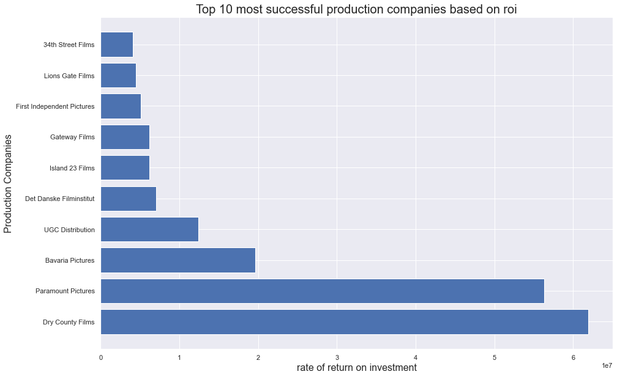

```python
fig = plt.figure(figsize=(15,10))
plt.barh(prod_roi.index,prod_roi)
plt.title('Top 10 most successful production companies based on roi', fontsize=20)
plt.xlabel('rate of return on investment', fontsize=16)
plt.ylabel('Production Companies', fontsize=16)
plt.show()
```

#### As can be seen in the plot above, the most successful production company is Dry County Films followed closely by Paramount Pictures.

## Conclusions

Limitations:

- Of the 10866 movies present in the dataset, around 10% contained missing values which were consequently dropped and this could affect the quality and accuracy of the analysis.
- Some of the variables like “Popularity, vote_count, vote_average” and many others were not defined in the original document from Kaggle which limits the ability to use it in the analysis.
- Due to the numerous zero records in the revenue and budget column, i replaced this 0 value with their respective means which could have also tampered with the quality and accuracy of my results.